# Pol Sci 200C Section: Sensitivity Analysis

Haotian (Barney) Chen

May 9, 2025

I develop this document largely based on materials from the `sensemakr` package [website](https://carloscinelli.com/sensemakr/articles/sensemakr.html). I also refer to lecture slides by Chad Hazlett, Fan Li, and Anton Strezhnev.

## Sensitivity Analysis

> Goal: had there were unmeasured confounders (omitted variables), what would happen?

Recall that our two main assumptions are conditional ignorability and common support. Can we test ignorability in observational studies? **No**. But there are some techniques (called falsification tests) to assess the imbalance:

- using placebo treatment/outcome that you know has null effect.
- multiple control groups: comparing treated with control group A, and comparing treated with control group B.
- using lagged outcomes (in panel data).

Sensitivity analysis is not a test, but more of a check. It provides a benchmark for the strength of the unobserved confounders. It won’t fix anything – it is for arguing.

### Cinelli and Hazlett (2020)

Formal Setting:

- Outcome $Y$, treatment $D$, observed (pre-treatment) covariates $X$, unobserved covariate(s) $Z$.
- $R^2_{D \sim Z|X}$ is the partial $R^2$ from regressing $D$ on $Z$ controlling for $X$ (proportion of variance explained in $D$ by $Z$, after controlling for $X$).
- $R^2_{Y \sim Z|X,D}$ is the partial $R^2$ from regressing $Y$ on $Z$ controlling for $X$ and conditioning on $D$.
- $|\widehat{\text{bias}}| = \sqrt{ \frac{R^2_{Y \sim Z \mid X, D} \, R^2_{D \sim Z \mid X}}{1 - R^2_{D \sim Z \mid X}} \, \frac{\mathbb{V}\left(Y^{\perp \mathbf{x}, D} \right)}{\mathbb{V}\left(D^{\perp \mathbf{x}} \right)}}$.

We will use data on attitudes of Darfurian refugees in eastern Chad to estimate the effects of exposure to violence on attitudes towards peace. You can check the original Cinelli and Hazlett (2020) [paper](https://doi.org/10.1177/0022002719879217).

```r
library(sensemakr)

data("darfur")
# run ?darfur to check this dataset
colnames(darfur)
```

```
##  [1] "wouldvote"           "peacefactor"         "peace_formerenemies"
##  [4] "peace_jjindiv"       "peace_jjtribes"      "gos_soldier_execute"
##  [7] "directlyharmed"      "age"                 "farmer_dar"
## [10] "herder_dar"          "pastvoted"           "hhsize_darfur"
## [13] "village"             "female"
```

The “treatment” variable of interest is `directlyharmed`, which indicates whether the individual was physically injured or maimed during the attack on her or his village in Darfur. The main outcome of interest is `peacefactor`, an index measuring pro-peace attitudes. ID strategy: SOO. The ID assumption is that, `directlyharmed` only depends on village and gender.

$$\text{PeaceIndex} =
\hat{\tau}_{\text{res}} \text{DirectHarm} + \hat{\beta}_{f,\text{res}}
\text{Female} + \text{Village} \hat{\beta}_{v,\text{res}} + \mathbf{X}
\hat{\beta}_{\text{res}} + \hat{\varepsilon}_{\text{res}}$$

```r
# run regression model
darfur.model <- lm(peacefactor ~ directlyharmed + village + female + age + farmer_dar
                   + herder_dar + pastvoted + hhsize_darfur, data = darfur)

stargazer::stargazer(darfur.model, keep = "directlyharmed", type = "text")
```

```
##
## ===============================================
##                         Dependent variable:
##                     ---------------------------
##                             peacefactor
## -----------------------------------------------
## directlyharmed               0.097***
##                               (0.023)
##
## -----------------------------------------------
## Observations                   1,276
## R2                             0.512
## Adjusted R2                    0.205
## Residual Std. Error      0.310 (df = 783)
## F Statistic          1.667*** (df = 492; 783)
## ===============================================
## Note:               *p<0.1; **p<0.05; ***p<0.01
```

#### sensemakr Package

The previous estimate requires the assumption of no unobserved confounders for unbiasedness.

```r
darfur.sensitivity <- sensemakr(model = darfur.model,
                                treatment = "directlyharmed",
                                benchmark_covariates = "female",
                                kd = 1:3,
                                ky = 1:3,
                                q = 1,
                                alpha = 0.05,
                                reduce = T)
darfur.sensitivity
```

```
## Sensitivity Analysis to Unobserved Confounding
##
## Model Formula: peacefactor ~ directlyharmed + village + female + age + farmer_dar +
##     herder_dar + pastvoted + hhsize_darfur
##
## Null hypothesis: q = 1 and reduce = TRUE
##
## Unadjusted Estimates of ' directlyharmed ':
##   Coef. estimate: 0.09732
##   Standard Error: 0.02326
##   t-value: 4.18445
##
## Sensitivity Statistics:
##   Partial R2 of treatment with outcome: 0.02187
##   Robustness Value, q = 1 : 0.13878
##   Robustness Value, q = 1 alpha = 0.05 : 0.07626
##
## For more information, check summary.
```

The arguments are:

- model: the `lm` object with the outcome regression. In our case, `darfur.model`.
- treatment: the name of the treatment variable. In our case, `directlyharmed`.
- benchmark_covariates (bound): the names of covariates that will be used to bound the plausible strength of the unobserved confounders. Here, we put `female`, which we argue to be among the main determinants of exposure to violence and find to be a strong determinant of attitudes towards peace.
- kd and ky: these arguments parameterize how many times stronger the confounder is related to the treatment (`kd`) and to the outcome (`ky`) in comparison to the observed benchmark covariate (`female`). In our example, setting `kd = 1:3` and `ky = 1:3` means we want to investigate the maximum strength of a confounder once, twice, or three times as strong as female (in explaining treatment and outcome variation). If only `kd` is given, `ky` will be set equal to it by default.
- q: this allows us to specify what percent change of the effect estimate that would have to be explained away to be problematic. Setting `q = 1`, as we do here, means that a reduction of 100% of the current effect estimate, that is, a true effect of zero, would be deemed problematic. The default is 1.
- alpha: significance level of interest for making statistical inferences. The default is 0.05.
- reduce: should we consider confounders acting towards increasing or reducing the absolute value of the estimate? The default is reduce = TRUE, which means we are considering confounders that pull the estimate towards (or through) zero.

We get these statistics:

```r
# sensitivity$sensitivity_stats
ovb_minimal_reporting(darfur.sensitivity, format = "html")
```

| Treatment | Outcome: peacefactor Est. | Outcome: peacefactor S.E. | Outcome: peacefactor t-value | Outcome: peacefactor $R^2_{Y \sim D \|{\bf X}}$ | Outcome: peacefactor $RV_{q = 1}$ | Outcome: peacefactor $RV_{q = 1, \alpha = 0.05}$ |
| --- | --- | --- | --- | --- | --- | --- |
| *directlyharmed* | 0.097 | 0.023 | 4.184 | 2.2% | 13.9% | 7.6% |
| Note: df = 783; Bound ( 1x female ): $R^2_{Y\sim Z\| {\bf X}, D}$ = 12.5%, $R^2_{D\sim Z\| {\bf X} }$ = 0.9% |  |  |  |  |  |  |

How should we interpret the results?

- The robustness value (**RV**) for bringing the point estimate of `directlyharmed` exactly to zero ($RV_{q=1}$) is 13.9%. This means that unobserved confounders that explain 13.9% of the residual variance both of the treatment and of the outcome are sufficiently strong to explain away all (here $q=1$) the observed effect. On the other hand, unobserved confounders that do not explain at least 13.9% of the residual variance both of the treatment and of the outcome are not sufficiently strong to do so.
- The robustness value (**RV**) for testing the null hypothesis that the coefficient of `directlyharmed` is zero ($RV_{q=1, \alpha=0.05}$) falls to 7.6%. This means that unobserved confounders that explain 7.6% of the residual variance both of the treatment and of the outcome are sufficiently strong to bring the lower bound of the confidence interval to zero (at the chosen significance level of 5%). On the other hand, unobserved confounders that do not explain at least 7.6% of the residual variance both of the treatment and of the outcome are not sufficiently strong to do so.
- The partial $R^2$ of `directlyharmed` with `peacefactor` ($R^2_{Y \sim D|X}$) means that, in an extreme scenario, in which we assume that unobserved confounders explain all of the left out variance of the outcome, these unobserved confounders would need to explain at least 2.2% of the residual variance of the treatment to bring the estimated effect down to zero.

You can get these from running:

```r
summary(darfur.sensitivity)
```

[output not shown]

#### Plots

##### Contour plot of point estimate

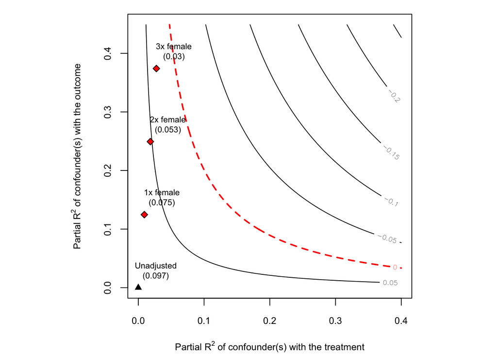

```r
plot(darfur.sensitivity)
```

The horizontal axis shows the hypothetical residual share of variation of the treatment that unobserved confounding explains, $R^2_{D \sim Z|X}$. The vertical axis shows the hypothetical partial $R^2$ of unobserved confounding with the outcome, $R^2_{Y \sim Z|X,D}$. Point estimate is robust to a confounder three times as strong as female.

##### Contour plot of t-statistics

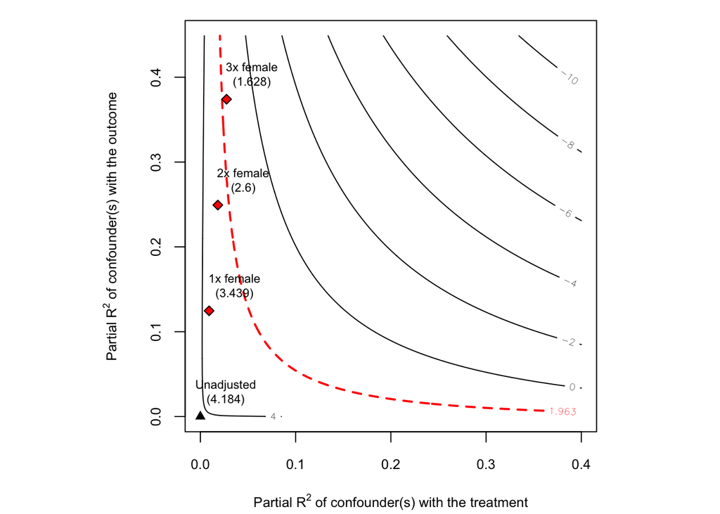

```r
# check ?plot.sensemakr
plot(darfur.sensitivity, sensitivity.of = "t-value")
```

The plot reveals that, at the 5% significance level, the null hypothesis of zero effect would still be rejected given confounders once or twice as strong as female. However, by contrast to the point-estimate, accounting for sampling uncertainty now means that the null hypothesis of zero effect would not be rejected with the inclusion of a confounder three times as strong as female.

##### Extreme scenario plot

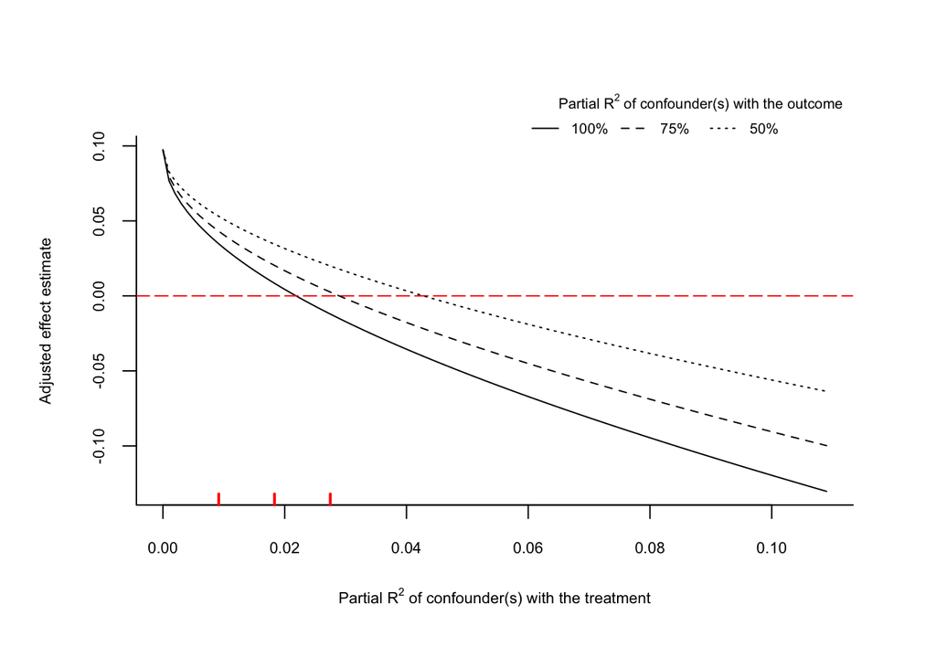

```r
plot(darfur.sensitivity, type = "extreme")
```

In the most extreme scenario, in which we assume that unobserved confounders explain all residual variance of the outcome ($R^2_{Y \sim Z|X,D}$ = 100%), confounders need to explain 2.2% of the residual variance of the treatment to bring the estimated effect down to zero. The plot shows that, even in the most extreme case of $R^2_{Y \sim Z|X,D}$ = 100%, confounders would need to be more than twice (red markers) as strongly associated with the treatment to fully explain away the point estimate. Moving to the scenarios $R^2_{Y \sim Z|X,D}$ = 75% and $R^2_{Y \sim Z|X,D}$ = 50%, confounders would need to be more than three times as strongly associated with the treatment as was female in order to fully explain away the point estimate.